# PROGETTO PER L’ESAME DI SCIENZA DEI DATI

Gianfranco Mauro

15/07/2021

# Introduzione

Questa è un’analisi sulle sparatorie (non vengono considerate le vittime del terrorismo) effettuate nelle Scuole e Università degli Stati Uniti da studenti o da altre persone accadute dal 1990 ad oggi.

L’obiettivo di questa analisi sarà quello di cercare di capire se esistono dei “pattern” presenti nella maggior parte delle sparatorie e infine capire quale tipologia di studente è più a rischio di incorrere in una sparatoria scolastica.

Breve descrizione delle variabili per il dataset sulle sparatorie:

- Date: data dell’accaduto
- City: luogo dell’accaduto
- State: uno dei 50 Stati dove sono avvenute le sparatorie
- Area Type: specifica se la scuola/univesità si trova in zona urbana, periferica o rurale
- School: C = Università, HS = scuole superiori, MS = scuole medie, ES = scuole elementari, - = non conosciuto
- Fatalities: # morti
- Wounded: # feriti

Breve descrizione delle variabili per il dataset delle scuole:

- Year: Anno
- Total.enrolled: somma degli studenti di tutti gli istituti iscritti in un determinato anno
- Public, Private: indicano se una scuola è pubblica o privata
- N, K, E, H, C: indicano rispettivamente se un istituto è una scuola di infermieristica, scuola dell’infanzia, scuola elementare, scuola superiore o un’Università

# Mappa degli Stati Uniti d’America che evidenzia la distribuzione delle vittime

In questa prima fase andremo ad analizzare la distribuzione dei decessi e delle sparatorie tramite una mappa degli USA e altri grafici correlati.

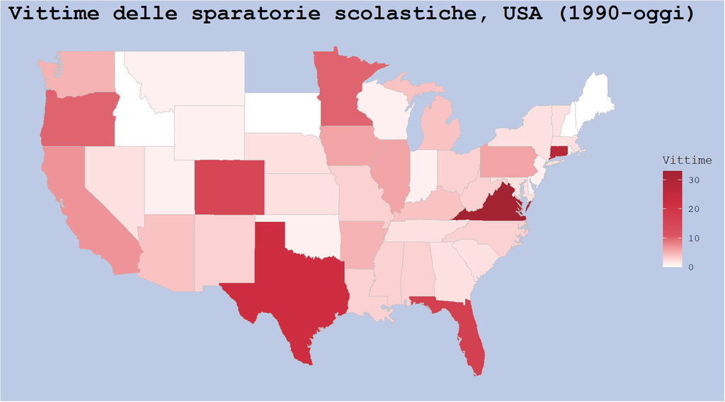

Possiamo vedere come gli Stati del Texas, Colorado, Florida, Connecticut e Virginia sono quelli con il maggior numero di morti nelle scuole, ovvero gli stati che liberalizzano di più le armi da fuoco e, considerando il numero di abitanti per ognuni di essi, sono proprio quelli con il maggior numero di armi da fuoco registrate pro capite.

## Stati con il maggior numero di sparatorie

E’ opportuno andare a controllare se c’è una relazione tra il numero di morti e il numero di sparatorie. Verifichiamo dunque se i 5 Stati sopracitati al punto precedente sono presenti anche in questa classificazione:

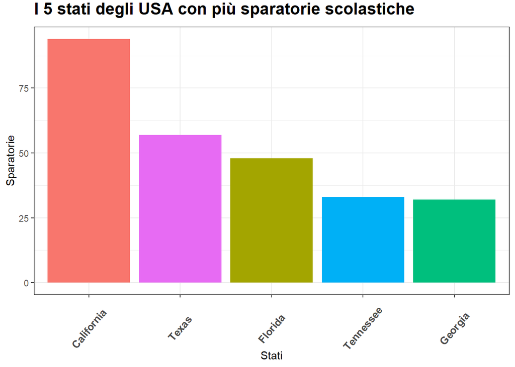

Troviamo che lo Stato della California ha un numero esorbitante di sparatorie, più di 80, ma non è presente nei 5 stati con più vittime, mentre Texas e Florida sono presenti in entrambi i grafici.

## Città statunitensi con il maggior numero di sparatorie

Ora, andiamo ad esaminare le 10 città statunitensi con i maggiori casi di sparatorie scolastiche degli ultimi anni:

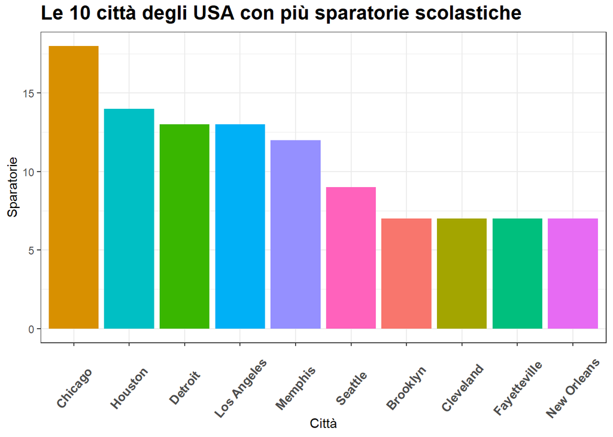

Notiamo subito come la Città di Chicago, Illinois è quella con il più alto numero di sparatorie, fatto che non mi stupisce in quanto è risaputo che è una delle città con la criminalità più alta degli Stati Uniti d’America.

Dopo Chicago troviamo rispettivamente:

-Houston, Texas

-Detroit, Michigan

-Los Angeles, California

-Memphis, Tennessee

Tutte con più di 10 casi registrati di sparatorie scolastiche.

# Distribuzione degli studenti nei vari istituti scolastici

Prima di analizzare il dataset sulle sparatorie in modo più specifico, analizziamo alcuni dati di base sulla popolazione scolastica, ovvero quanti studenti si iscrivono ogni anno e come si suddividono nei diversi livelli scolastici:

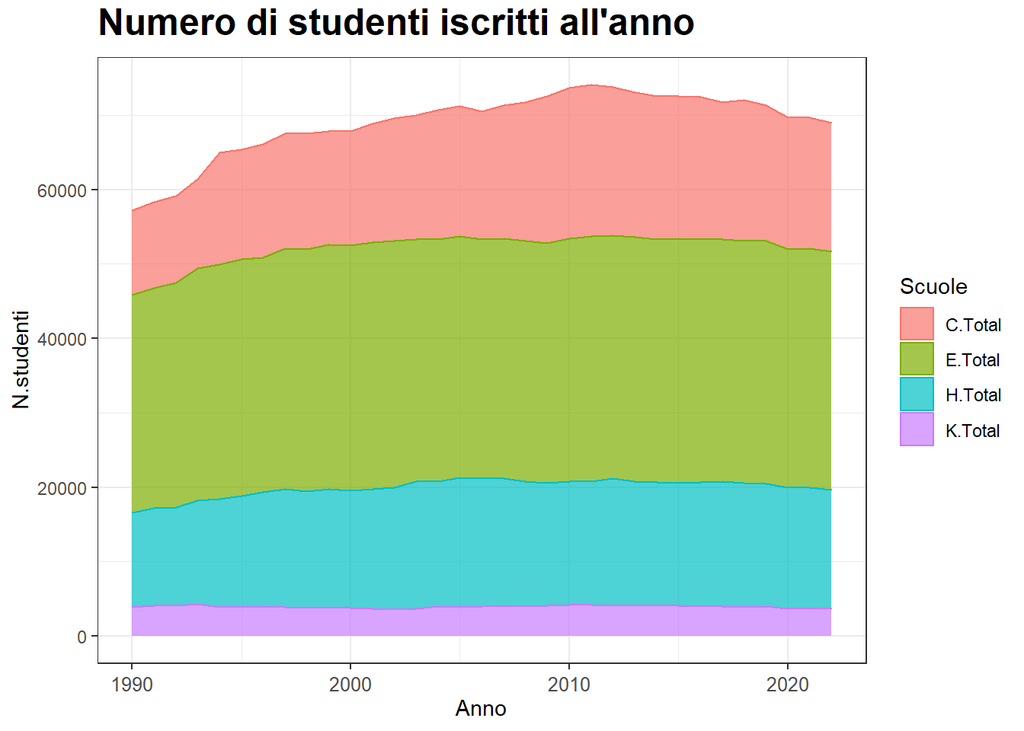

Successivamente capiremo perchè questi dati sono molto rilevanti per l’analisi.

# Numero di sparatorie e numero di morti negli istituti scolastici ed universitari per anno

Nei prossimi grafici, andremo ad osservare con precisione il numero delle sparatorie avvenute per anno e il numero dei morti derivati da esse.

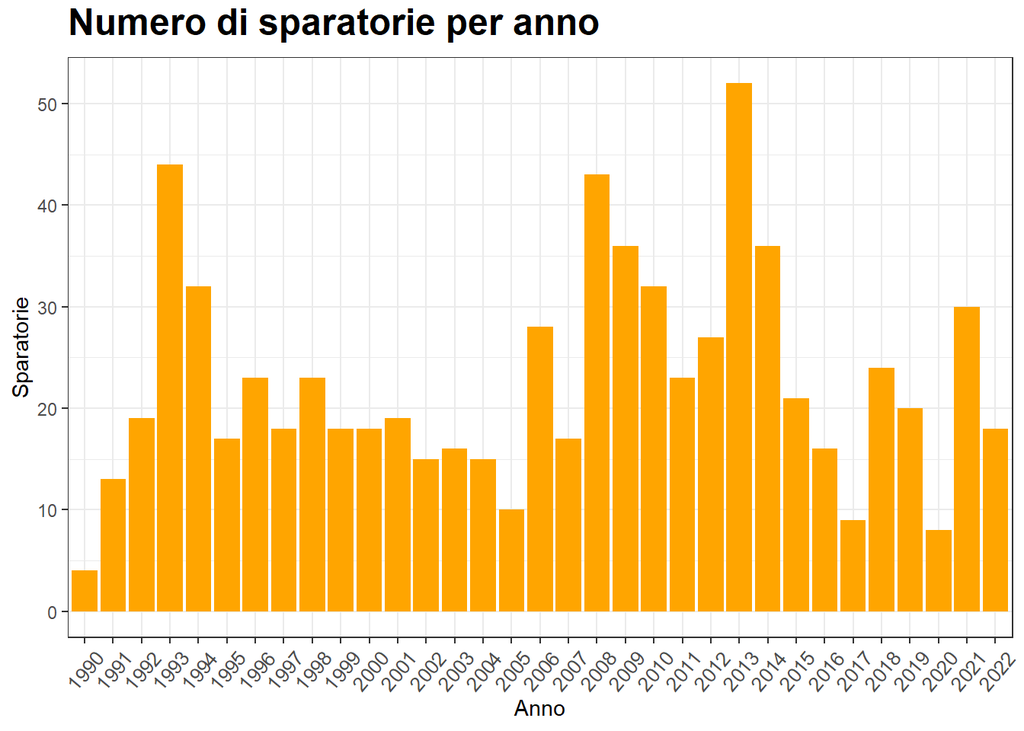

Da questo grafico possiamo fare le seguenti considerazioni:

- Notiamo come la media di sparatorie è di circa 20 all’anno, un numero a dir poco impressionante.
- Se dividiamo il grafico in due parti 1990-2005 e 2006-2022, la seconda metà vede una media di sparatorie leggermente più alta, influenzata sicuramente dal 2013, l’anno che ne ha avute di più.

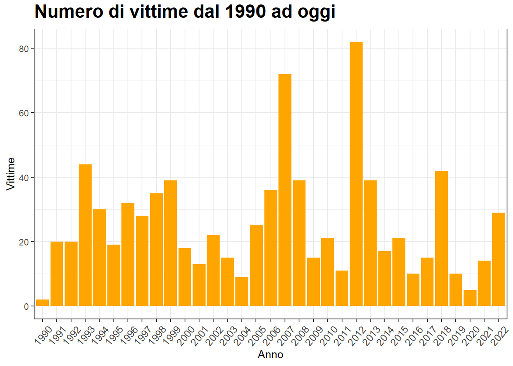

Cosa notiamo invece da questo grafico?

- Una delle prime cose che ho considerato è sicuramente il fatto che gli anni 2007 e 2012 hanno un numero di vittime sproporzionato rispetto a quelli precedenti o successivi. Ciò è certamente dovuto ai disastri del Virginia Polytechnic Institute and State University a Blacksburg in Virginia dove uno studente sud-koreano il 16-04-2007 ha ucciso 33 persone e ferite 17, e al massacro nella Sandy Hook Elementary School del Connecticut in cui un 20enne, il 14-12-2012, uccise 28 persone e ne ferì altre 2.
- Se mettiamo in relazione i due grafici che evidenziano il numero di sparatorie e di vittime negli anni si può vedere come non ci siano relazioni tra il numero alto di vittime e il numero alto di sparatorie, di fatto è proprio il contrario.
- Notiamo inoltre come nel 2022, nonostante l’anno non sia ancora concluso, il numero di vittime è relativamente alto, dovuto anch’esso dalla recente tragedia avvenuta il 24-05-2022 nella Robb Elementary School dove sono stati registrati 22 morti e 15 feriti.

Continuiamo ora la nostra analisi andando a verificare la tipologia di istituto più colpito da sparatorie e in quali di essi risultano più vittime in totale:

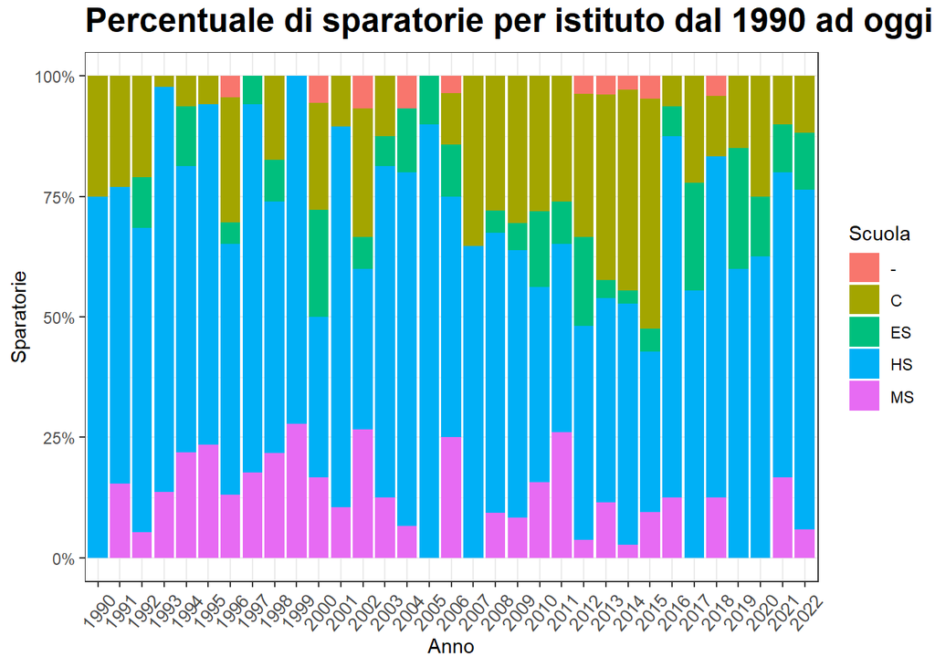

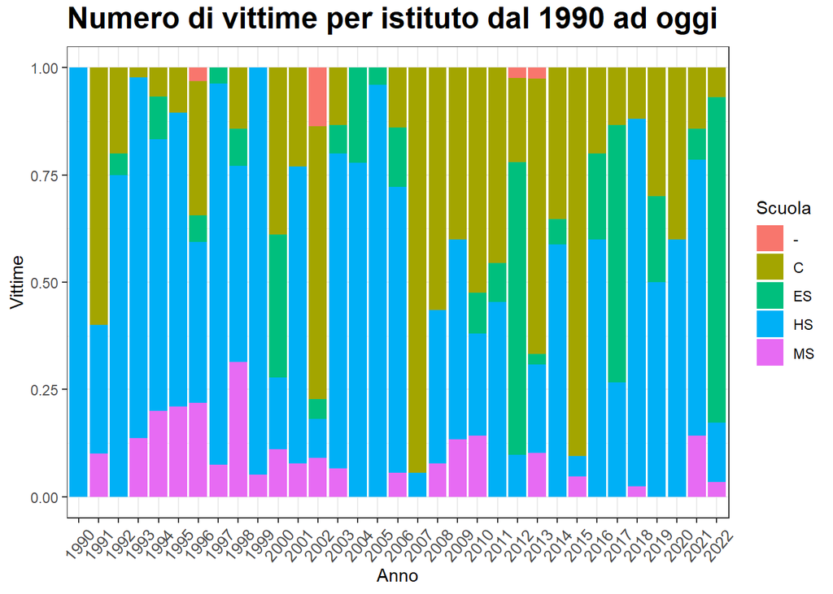

Da questi due grafici notiamo subito alcuni elementi:

- Le scuole superiori (HS) sono gli istututi più colpiti sia dal punto di vista delle sparatorie che delle vittime, seguite solo dalle Università (C).
- Come visto in precedenza, gli anni 2007 e 2012 sono stati quelli con più vittime in quanto in questi due periodi sono avvenute le due sparatorie con più decessi degli ultimi 32 anni.

A questo punto controlliamo quali sono le differenze tra il volume delle sparatorie e le tipologie di area:

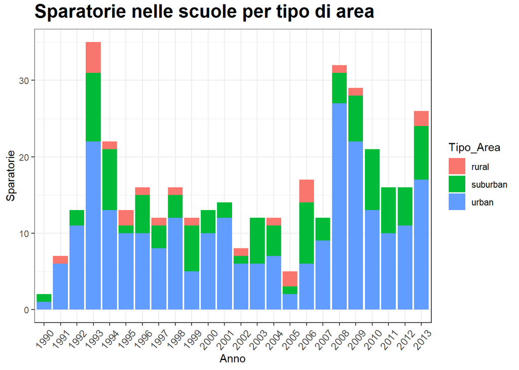

Il grafico ci mostra come la gran parte delle sparatorie scolastiche negli ultimi anni è avvenuta in area urbana. Ciò sta a significare che non c’è relazione tra condizioni di vita e il numero di avvenimenti.

Come ultima analisi, direi di andare a confrontare la frequenza delle sparatorie per tipologia di scuola e mese per vedere quale di questi ultimi sono più a rischio:

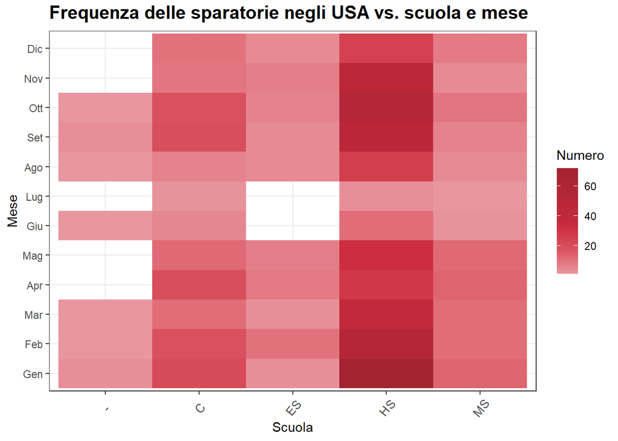